# Finding The Winning Formula: Examining NFL Positional Spending and Success Rates

By Noel Edah, Jordan Johnson, and Matt Gordon

### **Motivation**

The NFL is one of the most popular and lucrative sports leagues in the world with its popularity and profitability only increasing with each passing year. This explosion in profitability is resulting in players signing bigger contracts each year. As player contracts get larger, it becomes more important to spend this money prudently, to get the most bang for your buck. This careful thought into NFL spending can be seen in many ways such as the [devaluing of positions like running back.](https://bleacherreport.com/articles/2376840-will-wide-receivers-be-the-next-position-to-be-devalued) This begs the question: which positions are most important for winning? Or, what is the best allocation of spending on each position group to optimize winning?

In this project, we will look at NFL teams positional spending data from the last 10 NFL seasons (2013-2022) to try and answer this question

### **Part 1: Data Collection, Parsing, and Cleaning**

In this part of the data science lifecycle, we are going to collect our data. We'll begin by scraping NFL positional spending data from overthecap.com. They provide a positional spending table for each team, each year from 2013-2022. Since we eventually want to analyze the time frame as a whole, we need to loop through these tables and concatenate them into one big dataframe with a new observation to specify which year the row is from.

Once we clean the dataframe with all of our positional spending data, we need to then scrape a table from the internet to get the win percentages of each team from 2013-2022 and add it to our existing dataframe.

```python
import requests
from bs4 import BeautifulSoup
import pandas as pd
import numpy as np
import warnings
import matplotlib.pyplot as plt
from scipy import stats
import seaborn as sns
import sklearn

# Suppress FutureWarning messages
warnings.filterwarnings("ignore", category=FutureWarning)

# url of the tables we want
url = 'https://overthecap.com/positional-spending'

# using requests.get to store the html
html = requests.get(url).text

# using beautiful soup to clean up the html
soup = BeautifulSoup(html, 'html.parser')
BeautifulSoup = soup.prettify()

# using find_all to extract all the tables from the html
tables = soup.find_all('table')

# Now using pandas to get a list of dataframes, each dataframe is one of the yearly tables
table_dfs = pd.read_html(str(tables))

# Empty list we will populate with the dataframes after we add a year column
dfs = []

# List of years we will use to populate the year column
years = ['2013', '2014', '2015', '2016', '2017', '2018', '2019', '2020', '2021', '2022']

# Looping through each dataframe, adding a year column, and appending to dfs
for i in range(0, 10):
  tmp_df = table_dfs[i]
  tmp_df['Year'] = years[i]
  dfs.append(tmp_df)

# concatenating all of the dataframes together
df = pd.concat(dfs)

# Reset indices
df = df.reset_index(drop=True)

# Reordering the columns
cols = ['Team', 'Year', 'QB', 'RB', 'WR', 'TE', 'OL', 'IDL', 'EDGE', 'LB', 'S', 'CB', 'Offense', 'Defense']
df = df.reindex(columns=cols)

# Show result
df
```

|  | Team | Year | QB | RB | WR | TE | OL | IDL | EDGE | LB | S | CB | Offense | Defense |
| --- | --- | --- | --- | --- | --- | --- | --- | --- | --- | --- | --- | --- | --- | --- |
| 0 | Eagles | 2013 | $13,385,137 | $10,203,112 | $19,241,989 | $5,509,036 | $25,664,899 | $5,264,666 | $10,241,101 | $10,004,817 | $6,920,158 | $6,032,738 | $74,004,173 | $38,463,480 |
| 1 | Seahawks | 2013 | $1,557,085 | $10,799,653 | $16,831,423 | $12,778,788 | $27,955,261 | $7,701,509 | $25,013,832 | $7,377,232 | $8,579,619 | $3,507,877 | $69,922,210 | $52,180,069 |
| 2 | Titans | 2013 | $6,336,958 | $15,376,098 | $12,686,896 | $6,979,500 | $26,721,984 | $6,496,528 | $8,776,293 | $5,740,835 | $10,777,066 | $9,602,477 | $68,101,436 | $41,393,199 |
| 3 | Broncos | 2013 | $18,716,295 | $5,070,632 | $10,120,554 | $8,013,902 | $25,550,424 | $6,880,138 | $10,234,767 | $8,030,669 | $5,894,346 | $17,559,225 | $67,471,807 | $48,599,145 |
| 4 | Giants | 2013 | $21,998,400 | $5,036,739 | $8,677,626 | $2,998,913 | $24,235,900 | $5,118,995 | $9,523,813 | $7,916,847 | $12,704,990 | $11,202,110 | $62,947,578 | $46,466,755 |
| ... | ... | ... | ... | ... | ... | ... | ... | ... | ... | ... | ... | ... | ... | ... |
| 315 | Eagles | 2022 | $5,008,230 | $5,245,906 | $13,659,798 | $6,148,811 | $37,545,173 | $30,816,368 | $21,673,435 | $6,090,121 | $5,344,794 | $17,532,680 | $67,607,918 | $81,457,398 |
| 316 | Texans | 2022 | $3,856,318 | $5,480,218 | $16,068,691 | $3,710,583 | $37,408,894 | $7,425,859 | $15,929,240 | $12,683,243 | $9,515,023 | $16,819,387 | $66,524,704 | $62,372,752 |
| 317 | Falcons | 2022 | $6,303,695 | $4,894,510 | $9,535,858 | $10,678,128 | $32,848,444 | $18,104,464 | $6,077,102 | $4,917,321 | $4,468,126 | $14,033,033 | $64,260,635 | $47,600,046 |
| 318 | Bears | 2022 | $6,917,413 | $4,900,984 | $11,115,639 | $5,756,091 | $27,473,483 | $11,799,311 | $5,649,095 | $6,862,834 | $20,336,001 | $5,518,865 | $56,163,610 | $50,166,106 |
| 319 | Steelers | 2022 | $10,257,801 | $5,678,067 | $15,219,777 | $3,360,462 | $18,038,971 | $35,843,671 | $27,954,767 | $16,767,187 | $13,290,212 | $16,048,278 | $52,555,078 | $109,904,115 |

320 rows × 14 columns

### Let's change the spending values from strings to floats so we can do processing on them

```python
# For each spending column, get rid of the dollar sign and columns, then cast to a float
for column in df.columns:
  if column != 'Team' and column != 'Year':
    df[column] = df[column].str.replace('$', '').str.replace(',', '').astype(float)

# show result
df
```

|  | Team | Year | QB | RB | WR | TE | OL | IDL | EDGE | LB | S | CB | Offense | Defense |
| --- | --- | --- | --- | --- | --- | --- | --- | --- | --- | --- | --- | --- | --- | --- |
| 0 | Eagles | 2013 | 13385137.0 | 10203112.0 | 19241989.0 | 5509036.0 | 25664899.0 | 5264666.0 | 10241101.0 | 10004817.0 | 6920158.0 | 6032738.0 | 74004173.0 | 38463480.0 |
| 1 | Seahawks | 2013 | 1557085.0 | 10799653.0 | 16831423.0 | 12778788.0 | 27955261.0 | 7701509.0 | 25013832.0 | 7377232.0 | 8579619.0 | 3507877.0 | 69922210.0 | 52180069.0 |
| 2 | Titans | 2013 | 6336958.0 | 15376098.0 | 12686896.0 | 6979500.0 | 26721984.0 | 6496528.0 | 8776293.0 | 5740835.0 | 10777066.0 | 9602477.0 | 68101436.0 | 41393199.0 |
| 3 | Broncos | 2013 | 18716295.0 | 5070632.0 | 10120554.0 | 8013902.0 | 25550424.0 | 6880138.0 | 10234767.0 | 8030669.0 | 5894346.0 | 17559225.0 | 67471807.0 | 48599145.0 |
| 4 | Giants | 2013 | 21998400.0 | 5036739.0 | 8677626.0 | 2998913.0 | 24235900.0 | 5118995.0 | 9523813.0 | 7916847.0 | 12704990.0 | 11202110.0 | 62947578.0 | 46466755.0 |
| ... | ... | ... | ... | ... | ... | ... | ... | ... | ... | ... | ... | ... | ... | ... |
| 315 | Eagles | 2022 | 5008230.0 | 5245906.0 | 13659798.0 | 6148811.0 | 37545173.0 | 30816368.0 | 21673435.0 | 6090121.0 | 5344794.0 | 17532680.0 | 67607918.0 | 81457398.0 |
| 316 | Texans | 2022 | 3856318.0 | 5480218.0 | 16068691.0 | 3710583.0 | 37408894.0 | 7425859.0 | 15929240.0 | 12683243.0 | 9515023.0 | 16819387.0 | 66524704.0 | 62372752.0 |
| 317 | Falcons | 2022 | 6303695.0 | 4894510.0 | 9535858.0 | 10678128.0 | 32848444.0 | 18104464.0 | 6077102.0 | 4917321.0 | 4468126.0 | 14033033.0 | 64260635.0 | 47600046.0 |
| 318 | Bears | 2022 | 6917413.0 | 4900984.0 | 11115639.0 | 5756091.0 | 27473483.0 | 11799311.0 | 5649095.0 | 6862834.0 | 20336001.0 | 5518865.0 | 56163610.0 | 50166106.0 |
| 319 | Steelers | 2022 | 10257801.0 | 5678067.0 | 15219777.0 | 3360462.0 | 18038971.0 | 35843671.0 | 27954767.0 | 16767187.0 | 13290212.0 | 16048278.0 | 52555078.0 | 109904115.0 |

320 rows × 14 columns

### Add a new column that holds the total money spent by a team in that row's year

```python
# get rid of the observations that are not part of the calculation so we can sum across the row in one line
dropped = df.drop(columns=['Team', 'Year', 'Offense', 'Defense'])

# sum across the row of the temporary dataframe
df["Total Spent"] = dropped.sum(axis = 1)

# show result
df
```

|  | Team | Year | QB | RB | WR | TE | OL | IDL | EDGE | LB | S | CB | Offense | Defense | Total Spent |
| --- | --- | --- | --- | --- | --- | --- | --- | --- | --- | --- | --- | --- | --- | --- | --- |
| 0 | Eagles | 2013 | 13385137.0 | 10203112.0 | 19241989.0 | 5509036.0 | 25664899.0 | 5264666.0 | 10241101.0 | 10004817.0 | 6920158.0 | 6032738.0 | 74004173.0 | 38463480.0 | 112467653.0 |
| 1 | Seahawks | 2013 | 1557085.0 | 10799653.0 | 16831423.0 | 12778788.0 | 27955261.0 | 7701509.0 | 25013832.0 | 7377232.0 | 8579619.0 | 3507877.0 | 69922210.0 | 52180069.0 | 122102279.0 |
| 2 | Titans | 2013 | 6336958.0 | 15376098.0 | 12686896.0 | 6979500.0 | 26721984.0 | 6496528.0 | 8776293.0 | 5740835.0 | 10777066.0 | 9602477.0 | 68101436.0 | 41393199.0 | 109494635.0 |
| 3 | Broncos | 2013 | 18716295.0 | 5070632.0 | 10120554.0 | 8013902.0 | 25550424.0 | 6880138.0 | 10234767.0 | 8030669.0 | 5894346.0 | 17559225.0 | 67471807.0 | 48599145.0 | 116070952.0 |
| 4 | Giants | 2013 | 21998400.0 | 5036739.0 | 8677626.0 | 2998913.0 | 24235900.0 | 5118995.0 | 9523813.0 | 7916847.0 | 12704990.0 | 11202110.0 | 62947578.0 | 46466755.0 | 109414333.0 |
| ... | ... | ... | ... | ... | ... | ... | ... | ... | ... | ... | ... | ... | ... | ... | ... |
| 315 | Eagles | 2022 | 5008230.0 | 5245906.0 | 13659798.0 | 6148811.0 | 37545173.0 | 30816368.0 | 21673435.0 | 6090121.0 | 5344794.0 | 17532680.0 | 67607918.0 | 81457398.0 | 149065316.0 |
| 316 | Texans | 2022 | 3856318.0 | 5480218.0 | 16068691.0 | 3710583.0 | 37408894.0 | 7425859.0 | 15929240.0 | 12683243.0 | 9515023.0 | 16819387.0 | 66524704.0 | 62372752.0 | 128897456.0 |
| 317 | Falcons | 2022 | 6303695.0 | 4894510.0 | 9535858.0 | 10678128.0 | 32848444.0 | 18104464.0 | 6077102.0 | 4917321.0 | 4468126.0 | 14033033.0 | 64260635.0 | 47600046.0 | 111860681.0 |
| 318 | Bears | 2022 | 6917413.0 | 4900984.0 | 11115639.0 | 5756091.0 | 27473483.0 | 11799311.0 | 5649095.0 | 6862834.0 | 20336001.0 | 5518865.0 | 56163610.0 | 50166106.0 | 106329716.0 |
| 319 | Steelers | 2022 | 10257801.0 | 5678067.0 | 15219777.0 | 3360462.0 | 18038971.0 | 35843671.0 | 27954767.0 | 16767187.0 | 13290212.0 | 16048278.0 | 52555078.0 | 109904115.0 | 162459193.0 |

320 rows × 15 columns

### Let's convert the spending dollar values into a percentage of the total money spent. This will make data visualization much easier to understand and extract insight from.

```python
# Iterating through each row and column so we can change each appropriate column into a percentage of the 'Total Spent' column
for index, row in df.iterrows():
  for column in df.columns:
    if column != 'Year' and column != 'Team' and column != 'Total Spent':
      df.at[index, column] = round((df.at[index, column] / df.at[index, 'Total Spent']) * 100, 2)

# Show result
df
```

|  | Team | Year | QB | RB | WR | TE | OL | IDL | EDGE | LB | S | CB | Offense | Defense | Total Spent |
| --- | --- | --- | --- | --- | --- | --- | --- | --- | --- | --- | --- | --- | --- | --- | --- |
| 0 | Eagles | 2013 | 11.90 | 9.07 | 17.11 | 4.90 | 22.82 | 4.68 | 9.11 | 8.90 | 6.15 | 5.36 | 65.80 | 34.20 | 112467653.0 |
| 1 | Seahawks | 2013 | 1.28 | 8.84 | 13.78 | 10.47 | 22.89 | 6.31 | 20.49 | 6.04 | 7.03 | 2.87 | 57.27 | 42.73 | 122102279.0 |
| 2 | Titans | 2013 | 5.79 | 14.04 | 11.59 | 6.37 | 24.40 | 5.93 | 8.02 | 5.24 | 9.84 | 8.77 | 62.20 | 37.80 | 109494635.0 |
| 3 | Broncos | 2013 | 16.12 | 4.37 | 8.72 | 6.90 | 22.01 | 5.93 | 8.82 | 6.92 | 5.08 | 15.13 | 58.13 | 41.87 | 116070952.0 |
| 4 | Giants | 2013 | 20.11 | 4.60 | 7.93 | 2.74 | 22.15 | 4.68 | 8.70 | 7.24 | 11.61 | 10.24 | 57.53 | 42.47 | 109414333.0 |
| ... | ... | ... | ... | ... | ... | ... | ... | ... | ... | ... | ... | ... | ... | ... | ... |
| 315 | Eagles | 2022 | 3.36 | 3.52 | 9.16 | 4.12 | 25.19 | 20.67 | 14.54 | 4.09 | 3.59 | 11.76 | 45.35 | 54.65 | 149065316.0 |
| 316 | Texans | 2022 | 2.99 | 4.25 | 12.47 | 2.88 | 29.02 | 5.76 | 12.36 | 9.84 | 7.38 | 13.05 | 51.61 | 48.39 | 128897456.0 |
| 317 | Falcons | 2022 | 5.64 | 4.38 | 8.52 | 9.55 | 29.37 | 16.18 | 5.43 | 4.40 | 3.99 | 12.55 | 57.45 | 42.55 | 111860681.0 |
| 318 | Bears | 2022 | 6.51 | 4.61 | 10.45 | 5.41 | 25.84 | 11.10 | 5.31 | 6.45 | 19.13 | 5.19 | 52.82 | 47.18 | 106329716.0 |
| 319 | Steelers | 2022 | 6.31 | 3.50 | 9.37 | 2.07 | 11.10 | 22.06 | 17.21 | 10.32 | 8.18 | 9.88 | 32.35 | 67.65 | 162459193.0 |

320 rows × 15 columns

### Now that we have percentages, we need to change the column names to reflect this

```python
# Dictionary of name changes
col_names = {'QB': 'QB %', 'RB': 'RB %', 'WR': 'WR %', 'TE': 'TE %', 'OL': 'OL %', 'IDL': 'IDL %','EDGE': 'EDGE %', 'LB': 'LB %','S': 'S %','CB': 'CB %','Offense': 'Offense %','Defense': 'Defense %'}

# Changing the column names
df = df.rename(columns=col_names)

# Show result
df
```

|  | Team | Year | QB % | RB % | WR % | TE % | OL % | IDL % | EDGE % | LB % | S % | CB % | Offense % | Defense % | Total Spent |
| --- | --- | --- | --- | --- | --- | --- | --- | --- | --- | --- | --- | --- | --- | --- | --- |
| 0 | Eagles | 2013 | 11.90 | 9.07 | 17.11 | 4.90 | 22.82 | 4.68 | 9.11 | 8.90 | 6.15 | 5.36 | 65.80 | 34.20 | 112467653.0 |
| 1 | Seahawks | 2013 | 1.28 | 8.84 | 13.78 | 10.47 | 22.89 | 6.31 | 20.49 | 6.04 | 7.03 | 2.87 | 57.27 | 42.73 | 122102279.0 |
| 2 | Titans | 2013 | 5.79 | 14.04 | 11.59 | 6.37 | 24.40 | 5.93 | 8.02 | 5.24 | 9.84 | 8.77 | 62.20 | 37.80 | 109494635.0 |
| 3 | Broncos | 2013 | 16.12 | 4.37 | 8.72 | 6.90 | 22.01 | 5.93 | 8.82 | 6.92 | 5.08 | 15.13 | 58.13 | 41.87 | 116070952.0 |
| 4 | Giants | 2013 | 20.11 | 4.60 | 7.93 | 2.74 | 22.15 | 4.68 | 8.70 | 7.24 | 11.61 | 10.24 | 57.53 | 42.47 | 109414333.0 |
| ... | ... | ... | ... | ... | ... | ... | ... | ... | ... | ... | ... | ... | ... | ... | ... |
| 315 | Eagles | 2022 | 3.36 | 3.52 | 9.16 | 4.12 | 25.19 | 20.67 | 14.54 | 4.09 | 3.59 | 11.76 | 45.35 | 54.65 | 149065316.0 |
| 316 | Texans | 2022 | 2.99 | 4.25 | 12.47 | 2.88 | 29.02 | 5.76 | 12.36 | 9.84 | 7.38 | 13.05 | 51.61 | 48.39 | 128897456.0 |
| 317 | Falcons | 2022 | 5.64 | 4.38 | 8.52 | 9.55 | 29.37 | 16.18 | 5.43 | 4.40 | 3.99 | 12.55 | 57.45 | 42.55 | 111860681.0 |
| 318 | Bears | 2022 | 6.51 | 4.61 | 10.45 | 5.41 | 25.84 | 11.10 | 5.31 | 6.45 | 19.13 | 5.19 | 52.82 | 47.18 | 106329716.0 |
| 319 | Steelers | 2022 | 6.31 | 3.50 | 9.37 | 2.07 | 11.10 | 22.06 | 17.21 | 10.32 | 8.18 | 9.88 | 32.35 | 67.65 | 162459193.0 |

320 rows × 15 columns

### Our positional spending data looks clean, now we need to add win percentage from another website (betiq.teamrankings.com)

```python
# empty list to hold the win pct tables we get from each year
dfs = []

# iterating for 10 years and scraping a different url corresponding to the year each iteration
for i in range(0, 10):
  url = 'https://betiq.teamrankings.com/nfl/betting-trends/win-loss-records/?season=' + str(years[i])
  tmp_df = pd.read_html(url)[0]

  # Add year column
  tmp_df['Year'] = years[i]

  # drop unwanted columns
  tmp_df = tmp_df.drop(columns=['Win-Loss Record', 'MOV', 'ATS +/-'])

  # Add this year's df to the list
  dfs.append(tmp_df)

# Concatenate the dataframes and reindex
winpct_df = pd.concat(dfs)
winpct_df  = winpct_df.reindex(columns=['Team', 'Year', 'Win %'])

# Converting the percentages to floats
winpct_df['Win %'] = winpct_df['Win %'].str.replace('%', '').astype(float)

# Show result
winpct_df
```

|  | Team | Year | Win % |
| --- | --- | --- | --- |
| 0 | Seattle | 2013 | 84.2 |
| 1 | Denver | 2013 | 79.0 |
| 2 | San Francisco | 2013 | 73.7 |
| 3 | New England | 2013 | 72.2 |
| 4 | Carolina | 2013 | 70.6 |
| ... | ... | ... | ... |
| 27 | LA Rams | 2022 | 29.4 |
| 28 | Indianapolis | 2022 | 25.0 |
| 29 | Arizona | 2022 | 23.5 |
| 30 | Houston | 2022 | 18.8 |
| 31 | Chicago | 2022 | 17.7 |

320 rows × 3 columns

### Small Problem: our positional spending dataframe refers to teams by their team name and our win percentage dataframe refers to teams by their city. We will change the win pct dataframe to comply with team names

```python
# dictionary of city to team pairs
city_team = {
    'Arizona': 'Cardinals',
    'Atlanta': 'Falcons',
    'Baltimore': 'Ravens',
    'Buffalo': 'Bills',
    'Carolina': 'Panthers',
    'Chicago': 'Bears',
    'Cincinnati': 'Bengals',
    'Cleveland': 'Browns',
    'Dallas': 'Cowboys',
    'Denver': 'Broncos',
    'Detroit': 'Lions',
    'Green Bay': 'Packers',
    'Houston': 'Texans',
    'Indianapolis': 'Colts',
    'Jacksonville': 'Jaguars',
    'Kansas City': 'Chiefs',
    'Las Vegas': 'Raiders',
    'LA Chargers': 'Chargers',
    'LA Rams': 'Rams',
    'Miami': 'Dolphins',
    'Minnesota': 'Vikings',
    'New England': 'Patriots',
    'New Orleans': 'Saints',
    'NY Jets': 'Giants',
    'NY Giants': 'Jets',
    'Philadelphia': 'Eagles',
    'Pittsburgh': 'Steelers',
    'San Francisco': '49ers',
    'Seattle': 'Seahawks',
    'Tampa Bay': 'Buccaneers',
    'Tennessee': 'Titans',
    'Washington': 'Commanders'
}

# for each city we replace it with the team name
for city in city_team.keys():
  winpct_df['Team'] = winpct_df['Team'].str.replace(city, city_team[city])

# Show result
winpct_df
```

|  | Team | Year | Win % |
| --- | --- | --- | --- |
| 0 | Seahawks | 2013 | 84.2 |
| 1 | Broncos | 2013 | 79.0 |
| 2 | 49ers | 2013 | 73.7 |
| 3 | Patriots | 2013 | 72.2 |
| 4 | Panthers | 2013 | 70.6 |
| ... | ... | ... | ... |
| 27 | Rams | 2022 | 29.4 |
| 28 | Colts | 2022 | 25.0 |
| 29 | Cardinals | 2022 | 23.5 |
| 30 | Texans | 2022 | 18.8 |
| 31 | Bears | 2022 | 17.7 |

320 rows × 3 columns

### Now that we have the team representation consistent across both dataframes, we can merge them

```python
# merge on 'Team' and 'Year
df = pd.merge(df, winpct_df, on=['Team', 'Year'])

# Show Result
df
```

|  | Team | Year | QB % | RB % | WR % | TE % | OL % | IDL % | EDGE % | LB % | S % | CB % | Offense % | Defense % | Total Spent | Win % |
| --- | --- | --- | --- | --- | --- | --- | --- | --- | --- | --- | --- | --- | --- | --- | --- | --- |
| 0 | Eagles | 2013 | 11.90 | 9.07 | 17.11 | 4.90 | 22.82 | 4.68 | 9.11 | 8.90 | 6.15 | 5.36 | 65.80 | 34.20 | 112467653.0 | 58.8 |
| 1 | Seahawks | 2013 | 1.28 | 8.84 | 13.78 | 10.47 | 22.89 | 6.31 | 20.49 | 6.04 | 7.03 | 2.87 | 57.27 | 42.73 | 122102279.0 | 84.2 |
| 2 | Titans | 2013 | 5.79 | 14.04 | 11.59 | 6.37 | 24.40 | 5.93 | 8.02 | 5.24 | 9.84 | 8.77 | 62.20 | 37.80 | 109494635.0 | 43.8 |
| 3 | Broncos | 2013 | 16.12 | 4.37 | 8.72 | 6.90 | 22.01 | 5.93 | 8.82 | 6.92 | 5.08 | 15.13 | 58.13 | 41.87 | 116070952.0 | 79.0 |
| 4 | Giants | 2013 | 20.11 | 4.60 | 7.93 | 2.74 | 22.15 | 4.68 | 8.70 | 7.24 | 11.61 | 10.24 | 57.53 | 42.47 | 109414333.0 | 50.0 |
| ... | ... | ... | ... | ... | ... | ... | ... | ... | ... | ... | ... | ... | ... | ... | ... | ... |
| 315 | Eagles | 2022 | 3.36 | 3.52 | 9.16 | 4.12 | 25.19 | 20.67 | 14.54 | 4.09 | 3.59 | 11.76 | 45.35 | 54.65 | 149065316.0 | 80.0 |
| 316 | Texans | 2022 | 2.99 | 4.25 | 12.47 | 2.88 | 29.02 | 5.76 | 12.36 | 9.84 | 7.38 | 13.05 | 51.61 | 48.39 | 128897456.0 | 18.8 |
| 317 | Falcons | 2022 | 5.64 | 4.38 | 8.52 | 9.55 | 29.37 | 16.18 | 5.43 | 4.40 | 3.99 | 12.55 | 57.45 | 42.55 | 111860681.0 | 41.2 |
| 318 | Bears | 2022 | 6.51 | 4.61 | 10.45 | 5.41 | 25.84 | 11.10 | 5.31 | 6.45 | 19.13 | 5.19 | 52.82 | 47.18 | 106329716.0 | 17.7 |
| 319 | Steelers | 2022 | 6.31 | 3.50 | 9.37 | 2.07 | 11.10 | 22.06 | 17.21 | 10.32 | 8.18 | 9.88 | 32.35 | 67.65 | 162459193.0 | 52.9 |

320 rows × 16 columns

### This looks good! We have now collected both data sets, cleaned them up to fulfill our needs and match each other, and finally, combined it all into one dataframe ready for analysis.

### **Part 2 - Data Visualization & Exploratory Analysis**

```
<function matplotlib.pyplot.show(close=None, block=None)>
```

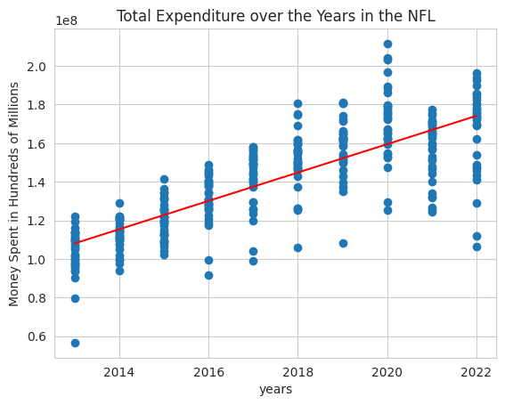

```python
x = df['Year'].astype(int)
y = df['Total Spent']
plt.scatter(x, y)
res = stats.linregress(x,y)
plt.plot(x, res.intercept + res.slope*x, 'r', label='fitted line')
plt.title("Total Expenditure over the Years in the NFL")
plt.xlabel("years")
plt.ylabel("Money Spent in Hundreds of Millions")
plt.show
```

Next we wanted to observe the distrubution of how each position is paid throughout the league. To do this, we constructed a violin plot with the positions along the x-axis and the percentage of the salary along the y-axis. This graph shows us that the offensive and defensive side of the ball are paid about equally. It also shows us that there seems to be two strategies in paying Quarterbacks as exemplified by their bimodality. In one camp, you pay them very little around 5% of your total expenditure. QBs in this camp are possibly on their rookie contract. In the other camp, you pay them much more, around 15% of your total expenditure. These QBs are likely more proven and have earned this money from their respective clubs. There are few teams that spend in that middle ground, around 10%.

For other position groups, the distributions are unimodal. Less than 5% of total expenditure goes to RB and TE. WRs make about 10% of total expenditure along with the defensive line, both interior and edge. Linebackers and safeties both tend to make up below 10% of total salary and cornerbacks tend to make up a little bit above 10% of total salary. The offensive lineman are typically the priciest item on an owners ledger in terms of the roster coming in at just under 20% of the cap.

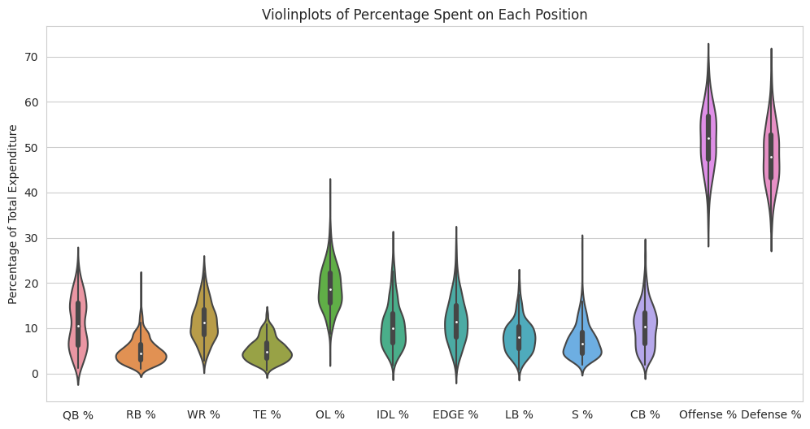

```python
temp_df = df.drop(columns=['Team', 'Year', 'Total Spent', 'Win %'])
fig, ax = plt.subplots(figsize=(12, 6))
sns.violinplot(data=temp_df, ax=ax)
ax.set_title('Violinplots of Percentage Spent on Each Position')
ax.set_ylabel('Percentage of Total Expenditure')
```

The bar graphs below are just another way to see how spending differs across the league. For each year, each teams expenditure was plotted as a bar graph of different colors representing expenditure on different position groups. This goes to show you that there are different strategies in spending across the league.

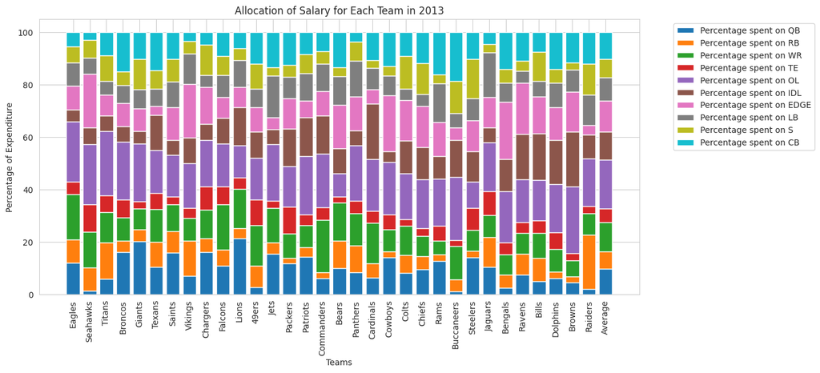

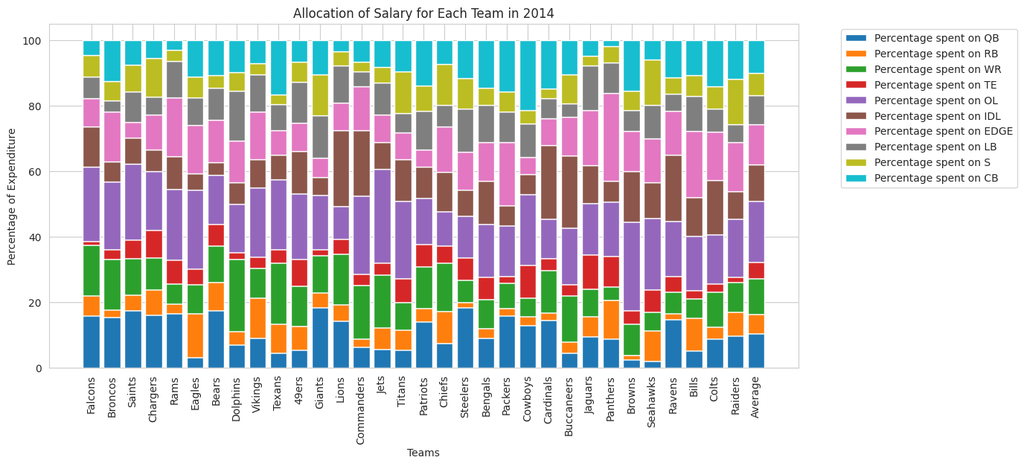

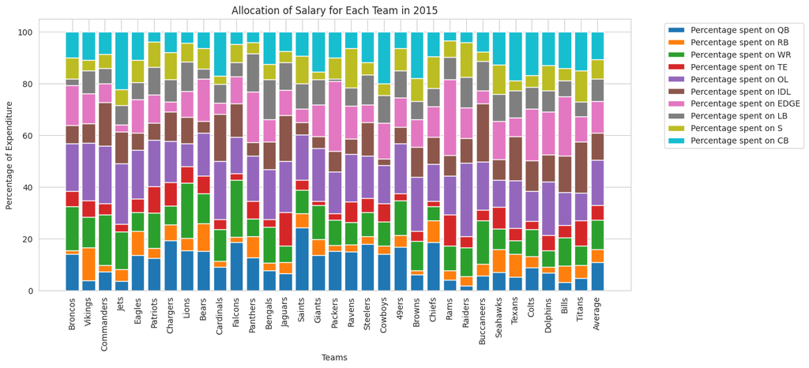

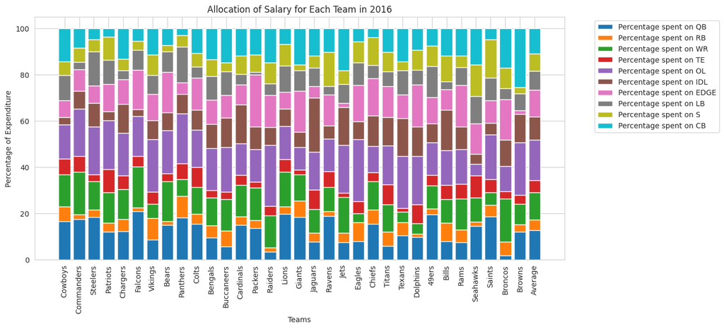

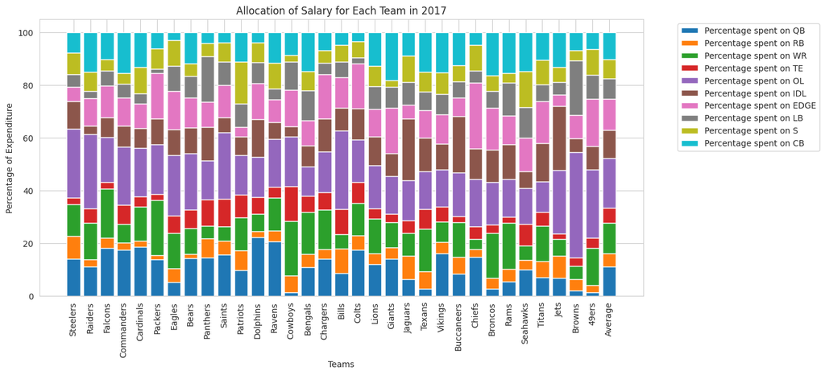

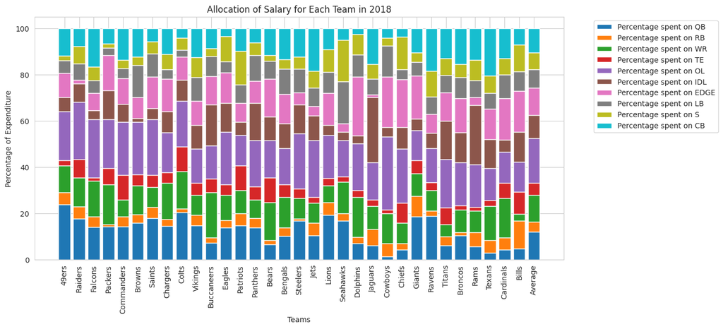

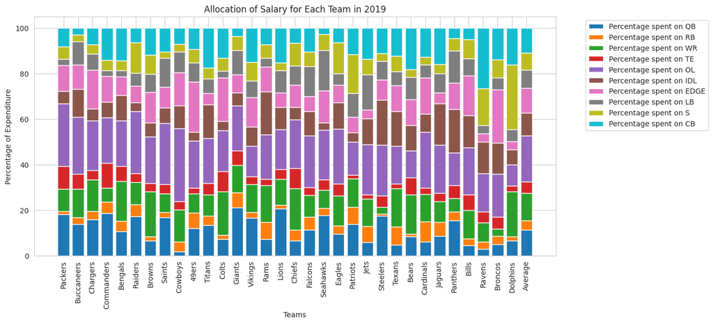

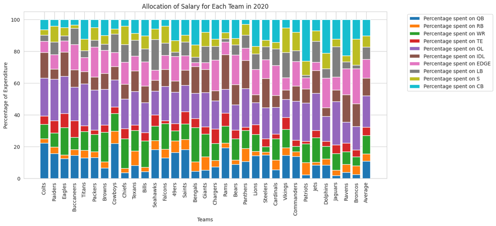

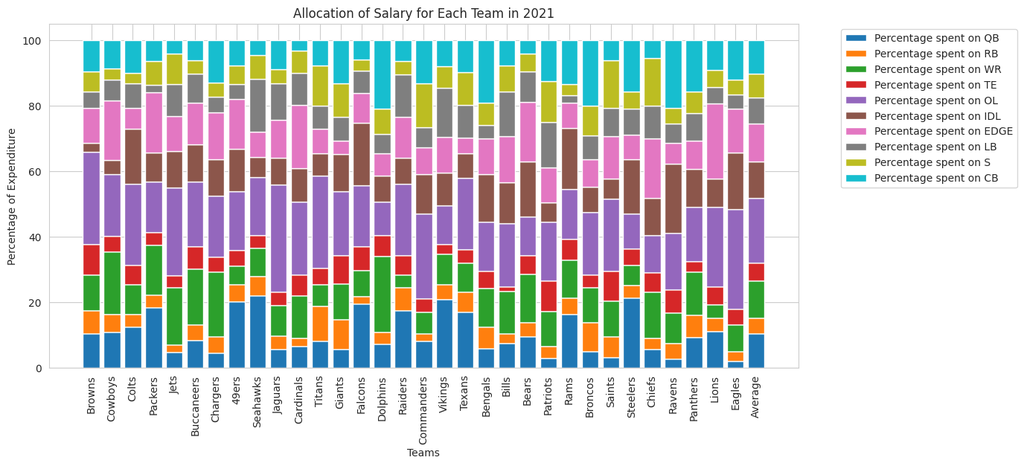

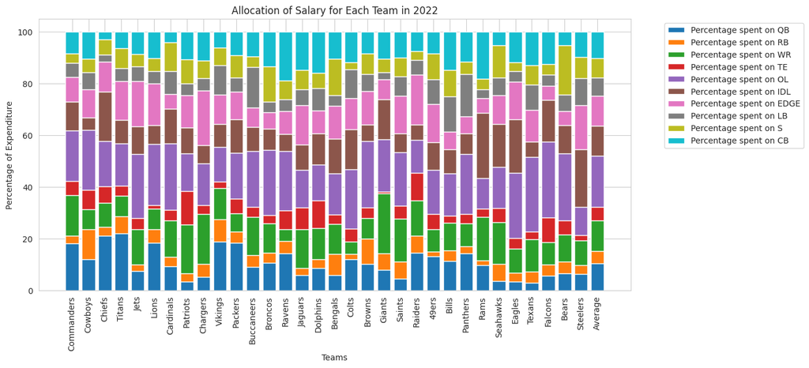

```python
for x in years:
  #isolate data for specific years and drop unnecessary columns
  data = df[df['Year'] == x]
  data = data.drop(columns=['Year', 'Offense %', 'Defense %', 'Total Spent', 'Win %'])

  # create figure for current year
  plt.figure(figsize=(13,6))

  # create input of average team spending for current year and add to data
  avg = {'Team':'Average', 'QB %':data['QB %'].mean(), 'RB %':data['RB %'].mean(), 'WR %':data['WR %'].mean(), 'TE %':data['TE %'].mean(), 'OL %':data['OL %'].mean(), 'IDL %':data['IDL %'].mean(), 'EDGE %':data['EDGE %'].mean(), 'LB %':data['LB %'].mean(), 'S %':data['S %'].mean(), 'CB %':data['CB %'].mean()}
  data = data.append(avg, ignore_index=True)

  # labels & titles for the plot
  plt.title("Allocation of Salary for Each Team in " + x)
  plt.xlabel("Teams")
  plt.ylabel("Percentage of Expenditure")

  #rotate team names and make it so the bars are stacked on top of each other
  plt.xticks(rotation=90)
  plt.bar(data['Team'], data['QB %'], label="Percentage spent on QB")
  plt.bar(data['Team'], data['RB %'], bottom=data['QB %'], label="Percentage spent on RB")
  plt.bar(data['Team'], data['WR %'], bottom=data['RB %']+data['QB %'], label="Percentage spent on WR")
  plt.bar(data['Team'], data['TE %'], bottom=data['WR %']+data['RB %']+data['QB %'], label="Percentage spent on TE")
  plt.bar(data['Team'], data['OL %'], bottom=data['TE %']+data['WR %']+data['RB %']+data['QB %'], label="Percentage spent on OL")
  plt.bar(data['Team'], data['IDL %'], bottom=data['OL %']+data['TE %']+data['WR %']+data['RB %']+data['QB %'], label="Percentage spent on IDL")
  plt.bar(data['Team'], data['EDGE %'], bottom=data['IDL %']+data['OL %']+data['TE %']+data['WR %']+data['RB %']+data['QB %'], label="Percentage spent on EDGE")
  plt.bar(data['Team'], data['LB %'], bottom=data['EDGE %']+data['IDL %']+data['OL %']+data['TE %']+data['WR %']+data['RB %']+data['QB %'], label="Percentage spent on LB")
  plt.bar(data['Team'], data['S %'], bottom=data['LB %']+data['EDGE %']+data['IDL %']+data['OL %']+data['TE %']+data['WR %']+data['RB %']+data['QB %'], label="Percentage spent on S")
  plt.bar(data['Team'], data['CB %'], bottom=data['S %']+data['LB %']+data['EDGE %']+data['IDL %']+data['OL %']+data['TE %']+data['WR %']+data['RB %']+data['QB %'], label="Percentage spent on CB")
  plt.legend(bbox_to_anchor=(1.05, 1.0), loc='upper left')
```

Now onto the interesting stuff. Much has been made about the "[rookie QB window](http://insidethepylon.com/nfl/front-office/2018/05/30/capitalizing-quarterbacks-rookie-contract/)" in the NFL. The rookie QB window theory suggests that the best time for a team to win is in a QBs rookie contract becuase productive QBs on rookie deals allow you to spend big elsewhere. Is this theory correct? Is there any position where being relatively cheap in your expenditure is correlated with success?

To answer these questions, we made scatter plots for each of the positions and plotted win percentage as a function of percentage of salary spent on that position. If the rookie QB theory is true, then we'd expect to see a negative trend in this scatter plot for QBs.

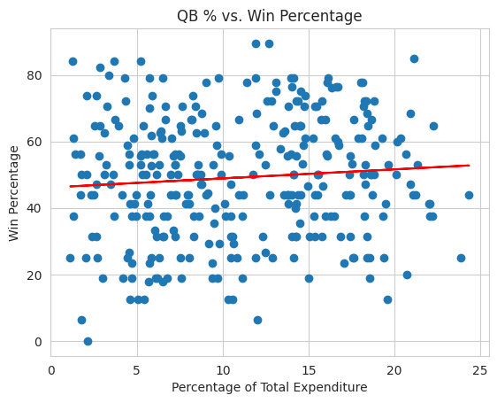

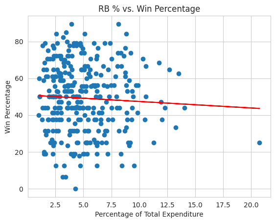

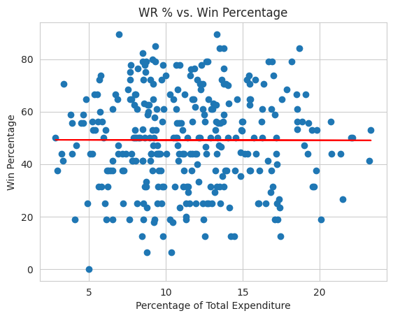

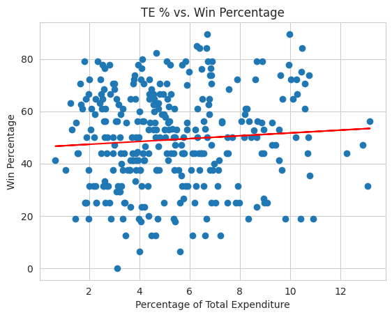

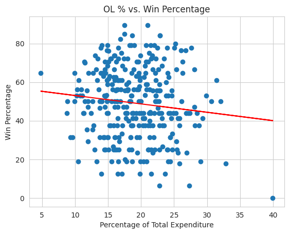

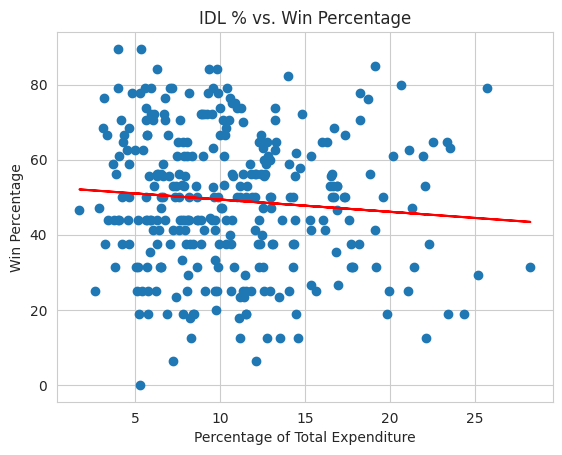

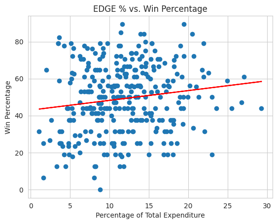

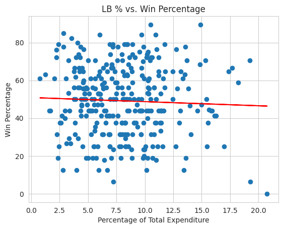

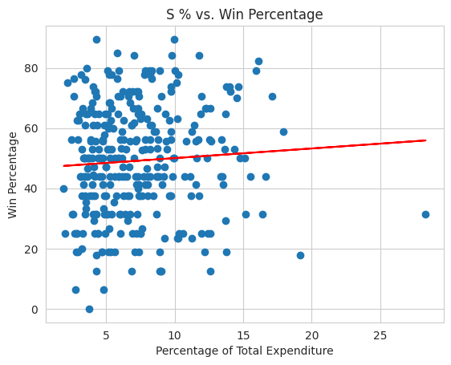

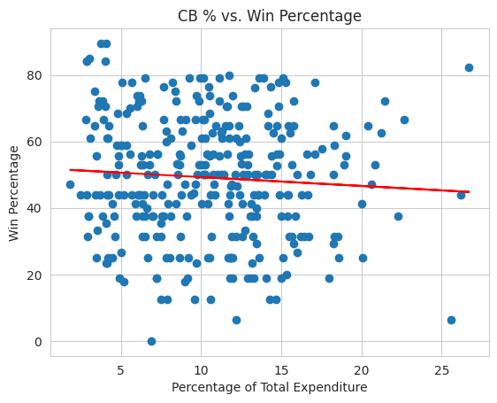

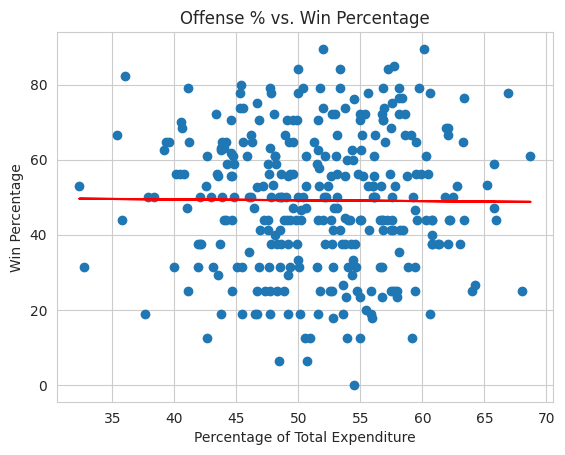

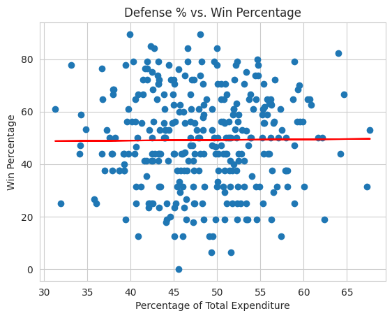

```python
temp_df = df.drop(columns=['Team', 'Year', 'Total Spent', 'Win %'])
positions = temp_df.columns
# plot percentage of total expenditure against win percentage for each position
for pos in positions:
  plt.figure()
  plt.scatter(df[pos], df['Win %'])
  plt.title(pos + " vs. Win Percentage")
  plt.xlabel("Percentage of Total Expenditure")
  plt.ylabel("Win Percentage")
  res = stats.linregress(df[pos], df['Win %'])
  plt.plot(df[pos], res.intercept + res.slope*df[pos], 'r', label='fitted line')
  plt.show()
```

These graphs suggest that the rookie QB window theory is not true. As stated above, if the theory was true, we'd expect to see a negative slope of the trend line in the QB scatter plot. What we actually observed was the opposite, a slight positive slope for the trendline, although the data obviously does not fit the trendline very well.

For all the other positions a similar story was told: the trendlines were not much different from horizontal lines, indicating little to no trend in the data and the trend line did not fit the data very well. This does not bode well for being able to establish a winning formula from this data.

## Part 3 - Analysis, Hypothesis Testing, Machine Learning##

At this point in the data science life cycle, we attempt to use various machine learning techniques to explain our data.

### Null Hypothesis analysis: There is no relationship between the cap allocation and winning percentage

```python
new_cols = {
    'Team': 'Team',
    'Year': 'Year',
    'QB %': 'QB_pct',
    'RB %': 'RB_pct',
    'WR %': 'WR_pct',
    'TE %': 'TE_pct',
    'OL %': 'OL_pct',
    'IDL %': 'IDL_pct',
    'EDGE %': 'EDGE_pct',
    'LB %': 'LB_pct',
    'S %': 'S_pct',
    'CB %': 'CB_pct',
    'Offense %': 'Offense_pct',
    'Defense %': 'Defense_pct',
    'Total Spent': 'Total_Spent',
    'Win %': 'Win_pct'
}
data = df.rename(columns=new_cols)


import statsmodels.formula.api as smf
model = smf.ols(formula='Win_pct ~ Offense_pct + Defense_pct', data=data)
result = model.fit()
print(result.summary())
```

```
                            OLS Regression Results
==============================================================================
Dep. Variable:                Win_pct   R-squared:                       0.000
Model:                            OLS   Adj. R-squared:                 -0.003
Method:                 Least Squares   F-statistic:                   0.02196
Date:                Fri, 12 May 2023   Prob (F-statistic):              0.882
Time:                        06:24:16   Log-Likelihood:                -1384.5
No. Observations:                 320   AIC:                             2773.
Df Residuals:                     318   BIC:                             2781.
Df Model:                           1
Covariance Type:            nonrobust
===============================================================================
                  coef    std err          t      P>|t|      [0.025      0.975]
-------------------------------------------------------------------------------
Intercept       0.0098      0.000     46.296      0.000       0.009       0.010
Offense_pct     0.4805      0.075      6.443      0.000       0.334       0.627
Defense_pct     0.5032      0.080      6.292      0.000       0.346       0.661
==============================================================================
Omnibus:                       12.559   Durbin-Watson:                   2.157
Prob(Omnibus):                  0.002   Jarque-Bera (JB):                6.413
Skew:                          -0.118   Prob(JB):                       0.0405
Kurtosis:                       2.348   Cond. No.                     5.17e+17
==============================================================================

Notes:
[1] Standard Errors assume that the covariance matrix of the errors is correctly specified.
[2] The smallest eigenvalue is 5.99e-30. This might indicate that there are
strong multicollinearity problems or that the design matrix is singular.
```

### Linear Regression

```python
model = smf.ols(formula='Win_pct ~ QB_pct + RB_pct + WR_pct + TE_pct + OL_pct + IDL_pct + EDGE_pct + LB_pct + S_pct + CB_pct', data=data)
result = model.fit()
print(result.summary())
```

```
                            OLS Regression Results
==============================================================================
Dep. Variable:                Win_pct   R-squared:                       0.053
Model:                            OLS   Adj. R-squared:                  0.022
Method:                 Least Squares   F-statistic:                     1.730
Date:                Fri, 12 May 2023   Prob (F-statistic):             0.0734
Time:                        06:24:19   Log-Likelihood:                -1375.8
No. Observations:                 320   AIC:                             2774.
Df Residuals:                     309   BIC:                             2815.
Df Model:                          10
Covariance Type:            nonrobust
==============================================================================
                 coef    std err          t      P>|t|      [0.025      0.975]
------------------------------------------------------------------------------
Intercept   1.164e+04    1.2e+04      0.971      0.332    -1.2e+04    3.52e+04
QB_pct      -115.6699    119.893     -0.965      0.335    -351.581     120.241
RB_pct      -116.1580    119.893     -0.969      0.333    -352.068     119.752
WR_pct      -115.8592    119.884     -0.966      0.335    -351.752     120.034
TE_pct      -115.5181    119.850     -0.964      0.336    -351.343     120.306
OL_pct      -116.1845    119.883     -0.969      0.333    -352.074     119.705
IDL_pct     -116.0519    119.891     -0.968      0.334    -351.957     119.853
EDGE_pct    -115.4113    119.863     -0.963      0.336    -351.262     120.440
LB_pct      -116.0009    119.859     -0.968      0.334    -351.844     119.842
S_pct       -115.5737    119.890     -0.964      0.336    -351.478     120.330
CB_pct      -115.9716    119.861     -0.968      0.334    -351.818     119.875
==============================================================================
Omnibus:                       16.477   Durbin-Watson:                   2.175
Prob(Omnibus):                  0.000   Jarque-Bera (JB):                6.972
Skew:                          -0.025   Prob(JB):                       0.0306
Kurtosis:                       2.279   Cond. No.                     4.01e+05
==============================================================================

Notes:
[1] Standard Errors assume that the covariance matrix of the errors is correctly specified.
[2] The condition number is large, 4.01e+05. This might indicate that there are
strong multicollinearity or other numerical problems.
```

### Residual Plot per year

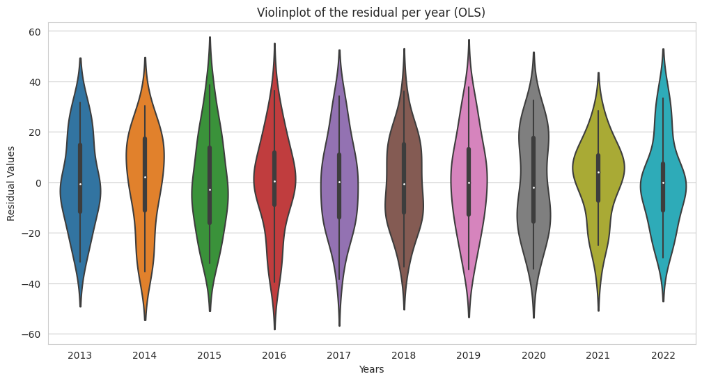

```python
year_2013 = np.array(result.resid[0:32]).reshape(32,)
year_2014 = np.array(result.resid[32:64]).reshape(32,)
year_2015 = np.array(result.resid[64:96]).reshape(32,)
year_2016 = np.array(result.resid[96:128]).reshape(32,)
year_2017 = np.array(result.resid[128:160]).reshape(32,)
year_2018 = np.array(result.resid[160:192]).reshape(32,)
year_2019 = np.array(result.resid[192:224]).reshape(32,)
year_2020 = np.array(result.resid[224:256]).reshape(32,)
year_2021 = np.array(result.resid[256:288]).reshape(32,)
year_2022 = np.array(result.resid[288:320]).reshape(32,)


data_to_plot = [year_2013, year_2014, year_2015, year_2016, year_2017, year_2018, year_2019, year_2020, year_2021, year_2022]
# Set up the plot
sns.set_style("whitegrid")
fig, ax = plt.subplots(figsize=(12, 6))
# Create the violin plot
sns.violinplot(data=data_to_plot, ax=ax)
# Set the x-axis labels
ax.set_xticklabels(["2013","2014", "2015", "2016", "2017", "2018", "2019", "2020", "2021", "2022"])

# Set the title and y-axis label
ax.set_title("Violinplot of the residual per year (OLS)")
ax.set_ylabel("Residual Values")
ax.set_xlabel("Years")
```

#### Residual plot analysis

As a last resort, we attempted to predict the win percentage of nfl teams using scikit learns MLPRegressor model. This model implements a Multi-Layer Perceptron to predict continuous values. The loss function it uses is squared error and it uses ReLu as the activation function. The activation function is important because it adds some nonlinearity to the model, allowing it to represent relationships that simple regressions like the ones above can't. The loss function provides a mean to assess the performance of the model. The solver is set as 'lbgfs' because the scikit learn specs say that lbgfs is best for working with small datasets like we're working with here.

We start by setting aside a small portion of the data to test the model with and removing it from the training pool. It is important not to train on the test data because you want to see how your model responds to new data. We chose to sample 10% or about 32 samples to test with later. The next steps were to drop the win %, year, and team from both the testing and training data. We don't want our model to take any of that information into account. From there, we then scaled the data using scikit learn because MLPs are sensitive to scaled features and scaling the data should result in improved performance. We also decreased the size of the hidden layer from the default of 100 to two layers of 4 and 3 nodes complexity to try and improve performance.

Even with these adjustments, we struggled to fit a model that's performance was much better than a horizontal line. In many instances of training the model, the model was actually worse than a horizintal line.

```python
from sklearn.neural_network import MLPRegressor
from sklearn.preprocessing import StandardScaler

# sample 10% of total datapoints for testing
test = df.sample(frac=0.1)
train = df

# drop testing data from training data
for ind in test.index:
  train = train.drop(index=ind)

# seperate the win percentage (value to predict) from the salary data and drop \
# unnecessary columns
train_y = train['Win %']
train_x = train.drop(columns=['Win %', 'Team', 'Year'])
test_y = test['Win %']
test_x = test.drop(columns=['Win %', 'Team', 'Year'])

#create scaler
scaler = StandardScaler()
scaler.fit(train_x.values)

#scale data
train_x = scaler.transform(train_x.values)
test_x = scaler.transform(test_x.values)

#create MLPRegressor and obtain R^2 (score)
reg = MLPRegressor(solver='lbfgs', max_iter=5000, hidden_layer_sizes=[4, 3])
reg.fit(train_x, train_y)
pred = reg.predict(test_x)
reg.score(test_x, test_y)
```

```
-0.3016626641517648
```

## Part 5 - Insight and Policy Decision

Ideally this analysis would be done with more data than we had. We were only able to find salary data going back to 2013, giving us about 320 datapoints to train and test models on, which is not a lot. More training examples would help improve our poor performance.